# BellaBeat: Fitness Tracker Analysis

Katherine Blake

2022-05-28

## Introduction

Bellabeat is a wellness and lifestyle brand focused on women’s health. They created the first wearable designed for women, and they are using the biometric data they collect to improve women’s health.

## Task Summary

The company’s founder and co-founder would like to look at general trends in people who own fitness trackers as a way to explore new avenues for marketing and improving user experience. Specifically, they would like to know if there’s anything in the data set that could help them understand their customers better or develop new marketing objectives. They requested an analysis of the [FitBit Fitness Tracker Data](https://www.kaggle.com/arashnic/fitbit), which is a public data set containing voluntary information from FitBit users.

## Sources and Integrity of Data

The FitBit’s Fitness Tracker Data is a publicly available set under a CC0 license that is available on Kaggle. I stored the raw data as csv files, which I loaded into RStudio. The data is not sensitive, so it doesn’t need to be secure.

The merits of the data are that it is publicly available data from a reliable source. Many people have produced analysis using it. I’ve reviewed several other projects using this data through Kaggle.[^1] Many of the gaps in the data are well known and described.

The limitations of the data include small sample size (in some cases, too small for the data to be usable), unknown demographics of the particpants in the study, and very little information about bias. It’s difficult to compare to the behavior of non-fitness tracker users, or people who didn’t participate, so it can be challenging to put into context.

There are 0 values in some of the cells, indicating that users may have had their trackers off at some point. However, I did not remove those points from the analysis. It could indicate, though, that means and quartiles for stats like total steps or calories burned may be low. Finally, it’s pre-COVID, so it may not reflect activity levels as accurately now.

### Tools I used

Here are the packages that I loaded into RStudio:

```r
install.packages("janitor")
install.packages("lubridate")
install.packages("skimr")
```

```r
install.packages("corrplot")
library(tidyverse)
library(janitor)
library(dplyr)
library(readr)
library(ggplot2)
library(skimr)
library(lubridate)
library(corrplot)
```

### Loading and Sorting Data sets

I used readr to link the csv files RStudio. I did not alter the csv files before loading.

```r
setwd("/cloud/project/Data/Fitabase Data 4.12.16-5.12.16")
activity <- read_csv("dailyActivity_merged.csv")
steps <- read_csv("dailySteps_merged.csv")
heartrate <- read_csv("heartrate_seconds_merged.csv")
calories <- read_csv("hourlyCalories_merged.csv")
intensities <- read_csv("hourlyIntensities_merged.csv")
sleep <- read_csv("sleepDay_merged.csv")
weight <- read_csv("weightLogInfo_merged.csv")
```

## Cleaning and formatting the data

In addition, I inspected the data, and then formatted the dates in order to merge the tables. To see full documentation of cleaning, inspection, and formatting, [view my RScript on GitHub](https://github.com/katherineeblake/katherineeblake/commit/7db976fb84eaf2ab96a699fee3ed8c830355200d).

```r
setwd("/cloud/project/Data/Fitabase Data 4.12.16-5.12.16")

## Formatting Data
intensities$ActivityHour=as.POSIXct(intensities$ActivityHour, format="%m/%d/%Y %I:%M:%S %p", tz=Sys.timezone())
intensities$time <- format(intensities$ActivityHour, format = "%H:%M:%S")
intensities$date <- format(intensities$ActivityHour, format = "%m/%d/%y")
# calories
calories$ActivityHour=as.POSIXct(calories$ActivityHour, format="%m/%d/%Y %I:%M:%S %p", tz=Sys.timezone())
calories$time <- format(calories$ActivityHour, format = "%H:%M:%S")
calories$date <- format(calories$ActivityHour, format = "%m/%d/%y")
# activity
activity$ActivityDate=as.POSIXct(activity$ActivityDate, format="%m/%d/%Y", tz=Sys.timezone())
activity$date <- format(activity$ActivityDate, format = "%m/%d/%y")
# sleep
sleep$SleepDay=as.POSIXct(sleep$SleepDay, format="%m/%d/%Y %I:%M:%S %p", tz=Sys.timezone())
sleep$date <- format(sleep$SleepDay, format = "%m/%d/%y")
```

Finally, I counted the number of distinct IDs in order to determine how many people had submitted data in each of the categories.

```r
## Finding out how many participants in each set
setwd("/cloud/project/Data/Fitabase Data 4.12.16-5.12.16")
n_distinct(activity$Id)
```

```
## [1] 33
```

```r
n_distinct(calories$Id)
```

```
## [1] 33
```

```r
n_distinct(intensities$Id)
```

```
## [1] 33
```

```r
n_distinct(sleep$Id)
```

```
## [1] 24
```

```r
n_distinct(weight$Id)
```

```
## [1] 8
```

```r
n_distinct(heartrate$Id)
```

```
## [1] 14
```

## Summarizing Datasets

Before plotting the data, I wanted to look at some basic information about the elements I chose to focus on, including means, medians, and quartile breakdowns. I summarize my findings in the analysis section below.

```r
setwd("/cloud/project/Data/Fitabase Data 4.12.16-5.12.16")

# activity
activity %>%
  select(TotalSteps, TotalDistance, SedentaryMinutes, Calories) %>%
  summary()
```

```
##    TotalSteps    TotalDistance    SedentaryMinutes    Calories
##  Min.   :    0   Min.   : 0.000   Min.   :   0.0   Min.   :   0
##  1st Qu.: 3790   1st Qu.: 2.620   1st Qu.: 729.8   1st Qu.:1828
##  Median : 7406   Median : 5.245   Median :1057.5   Median :2134
##  Mean   : 7638   Mean   : 5.490   Mean   : 991.2   Mean   :2304
##  3rd Qu.:10727   3rd Qu.: 7.713   3rd Qu.:1229.5   3rd Qu.:2793
##  Max.   :36019   Max.   :28.030   Max.   :1440.0   Max.   :4900
```

```r
# explore num of active minutes per category
activity %>%
  select(VeryActiveMinutes, FairlyActiveMinutes, LightlyActiveMinutes) %>%
  summary()
```

```
##  VeryActiveMinutes FairlyActiveMinutes LightlyActiveMinutes
##  Min.   :  0.00    Min.   :  0.00      Min.   :  0.0
##  1st Qu.:  0.00    1st Qu.:  0.00      1st Qu.:127.0
##  Median :  4.00    Median :  6.00      Median :199.0
##  Mean   : 21.16    Mean   : 13.56      Mean   :192.8
##  3rd Qu.: 32.00    3rd Qu.: 19.00      3rd Qu.:264.0
##  Max.   :210.00    Max.   :143.00      Max.   :518.0
```

```r
# calories
calories %>%
  select(Calories) %>%
  summary()
```

```
##     Calories
##  Min.   : 42.00
##  1st Qu.: 63.00
##  Median : 83.00
##  Mean   : 97.39
##  3rd Qu.:108.00
##  Max.   :948.00
```

```r
# sleep
sleep %>%
  select(TotalSleepRecords, TotalMinutesAsleep, TotalTimeInBed) %>%
  summary()
```

```
##  TotalSleepRecords TotalMinutesAsleep TotalTimeInBed
##  Min.   :1.000     Min.   : 58.0      Min.   : 61.0
##  1st Qu.:1.000     1st Qu.:361.0      1st Qu.:403.0
##  Median :1.000     Median :433.0      Median :463.0
##  Mean   :1.119     Mean   :419.5      Mean   :458.6
##  3rd Qu.:1.000     3rd Qu.:490.0      3rd Qu.:526.0
##  Max.   :3.000     Max.   :796.0      Max.   :961.0
```

## Key Findings

### Finding One: Lightly active people may be less sedentary overall

Negative correlation between sedentary minutes and lightly active minutes is stronger than between any other categories of intensity. That means people who are lightly active are more active overall than any other category.

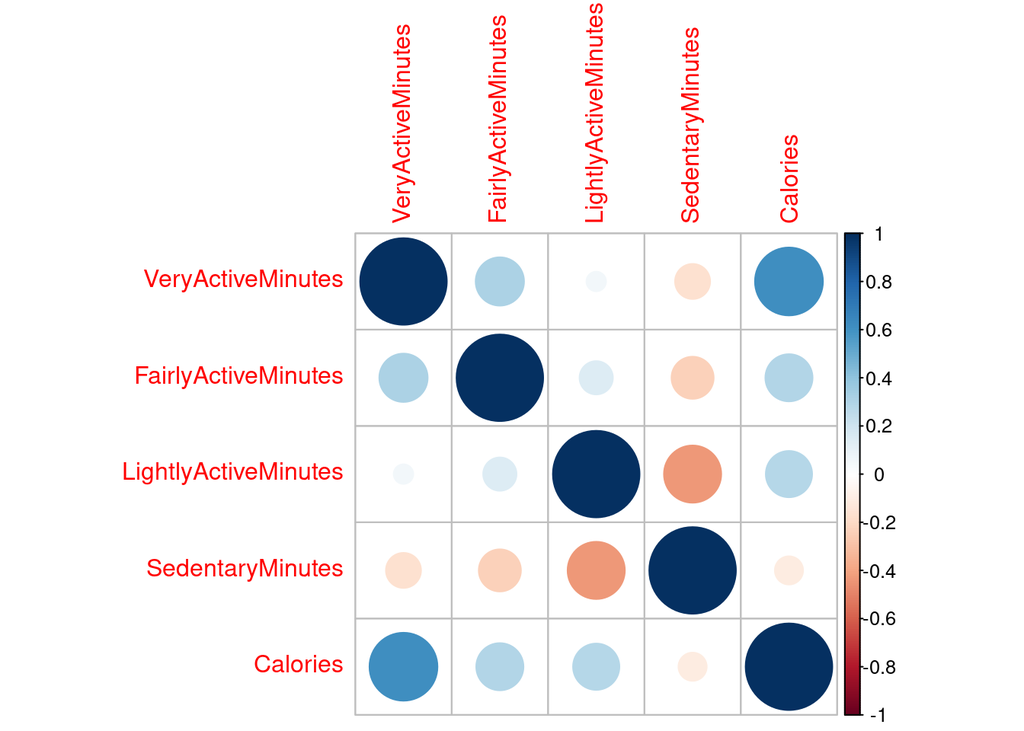

### Finding Two: Most Fitbit Users Burn Calories Consistent with a Lightly Active Lifestyle or Better

However, the average sedentary person (men and women included) from least to greatest burns between 1800 and 2600 calories per day.[^2] Assuming that at least some of these users are women, and knowing that some values are 0 (probably representing times that people weren’t wearing their FitBits), that number is probably low. Moreover, FitBit users report an average of 3.2 hours of light activity per day. Therefore, I concluded that most FitBit users are better described as “Lightly Active” than “Sedentary.”

**Calories**  
Min. : 0  
1st Qu.:1828  
Median :2134  
Mean :2304  
3rd Qu.:2793  
Max. :4900

**Lightly Active**  
Min. :0.0  
1st Qu.:127.0  
Median :199.0  
Mean :192.8  
3rd Qu.:264.0  
Max. :518.0

### Finding Three: Light Activity burns significant calories

Light activity does have a significant impact on calorie burn. Moreover, light activity accounts for a much greater share of overall activity than any category. This, combined with finding two, suggests that there are compelling reasons to focus on light activity if you want to burn calories.

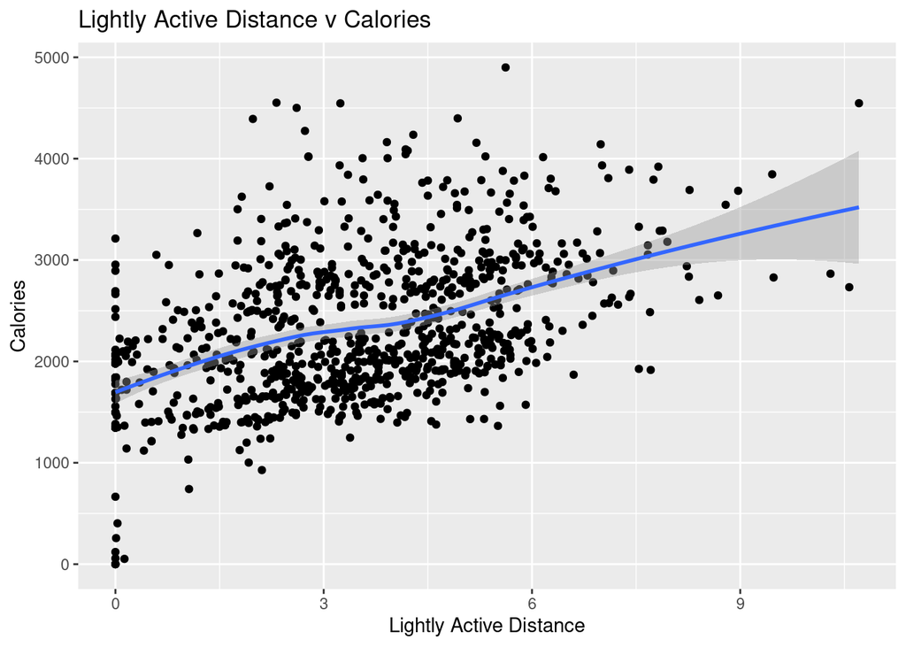

```r
setwd("/cloud/project/Data/Fitabase Data 4.12.16-5.12.16")

## Light activity v. Calories
ggplot(activity, aes(LightActiveDistance, Calories)) +
  geom_point() +
  geom_smooth() +
  labs(title = "Lightly Active Distance v Calories", x = "Lightly Active Distance", y = "Calories")
```

### Other Findings

#### Wearers are Most Active in the Evenings

Wearers tend to be most active in the evening Users are most active in the evening, between 5:00PM and 7:00PM. They are least active between 1:00 AM and 5:00 AM. Activity tends to drop greatly after 8:00PM, whereas it tends to display an upward trend from 5:00 AM until the afternoon.

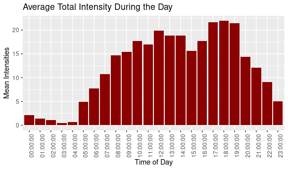

#### Fitbit Users Get Recommended Sleep on Average

Mean : 419.5 Mean : 458.6  
3rd Qu.: 490.0 3rd Qu.: 526.0

## Recommendations

*More research is necessary, but it does appear that light activity accounts for a significant amount of total activity as well as calories burned. There is also a stronger negative correlation between being lightly active and being sedentary than other categories of activity. Light activity is probably a better lifestyle fit for most people. Moreover, most Fitbit users are already lightly active. I suggest a campaign on the benefits of being lightly active should focus on making people feel good about making the choices that are within their reach. This campaign could focus on the benefits of a lightly active lifestyle while underscoring how fitness tracker wearers tend to be lightly active.

*Notifications that compare users’ data to averages and quarter measurements for calories and activity. For example, if you burn more than 75% of daily calories than other users, you should get a notification congratulating you. Notifications could also apply to steps, distance, and minutes of activity.

**Thank you for taking time with my analysis. Please reach out to me if you have any questions.**

## Citations

[^1]: RodneyX, Bellabeat Wellness Case Study, https://www.kaggle.com/code/rodneyx/bellabeat-wellness-case-study and Irene Zurovac, Bellabeat Case Study Using R, https://www.kaggle.com/code/irenezurovec/bellabeat-case-study-using-r
[^2]: Kathleen M. Zelman, “How Many Calories Do You Really Need?” *WebMD* https://www.webmd.com/diet/guide/calories-chart
[^3]: CDC, “How Much Sleep Do I Need?” https://www.cdc.gov/sleep/about_sleep/how_much_sleep.html